# survidm: An R package for Inference and Prediction in an Illness-Death Model

Gustavo Soutinho

University of Porto

Marta Sestelo

University of Vigo

Luís Meira-Machado

University of Minho

2021-08-17

Abstract

Multi-state models are a useful way of describing a process in which an individual moves through a number of finite states in continuous time. The illness-death model plays a central role in the theory and practice of these models, describing the dynamics of healthy subjects who may move to an intermediate "diseased" state before entering into a terminal absorbing state. In these models, one important goal is the modeling of transition rates which is usually done by studying the relationship between covariates and disease evolution. However, biomedical researchers are also interested in reporting other interpretable results in a simple and summarized manner. These include estimates of predictive probabilities, such as the transition probabilities, occupation probabilities, cumulative incidence functions, and the sojourn time distributions. The development of [*survidm*](https://CRAN.R-project.org/package=survidm) package has been motivated by recent contribution that provides answers to all these topics. An illustration of the software usage is included using real data.

# Introduction

Multi-state models are very useful for describing complex event history data with multiple endpoints. These models may be considered a generalization of survival analysis where survival is the ultimate outcome of interest but where information is available about intermediate events which individuals may experience during the study period. For instance, in most biomedical applications, besides the ‘healthy’ initial state and the absorbing ‘dead’ state, one may observe intermediate (transient) states based on health conditions (e.g., diseased), disease stages (e.g., stages of cancer or HIV infection), clinical symptoms (e.g., bleeding episodes), biological markers (e.g., CD4 T-lymphocyte cell counts; serum immunoglobulin levels), or they can represent a non-fatal complication in the course of the illness (e.g., cancer recurrence, transplantation, etc.). Graphically, these models may be illustrated using diagrams with boxes representing the states and with arrows between the states representing the possible transitions. The complexity of the multi-state model greatly depends on the number of states and also on the possible transitions. The illness-death model is probably the most popular one in the medical literature. The irreversible version of this model (Figure 1) describes the pathway from an initial state to an absorbing state either directly or through an intermediate state. Many event-history data sets from biomedical studies with multiple endpoints can be reduced to this generic structure. There exists extensive literature on multi-state models. Main contributions include books by Andersen et al. (1993) and Hougaard (2000) (Chapter 5 and 6). Recent reviews on this topic may be found in the papers by H. Putter, Fiocco, and Geskus (2007), L. Meira-Machado et al. (2009), and L. Meira-Machado and Sestelo (2019).

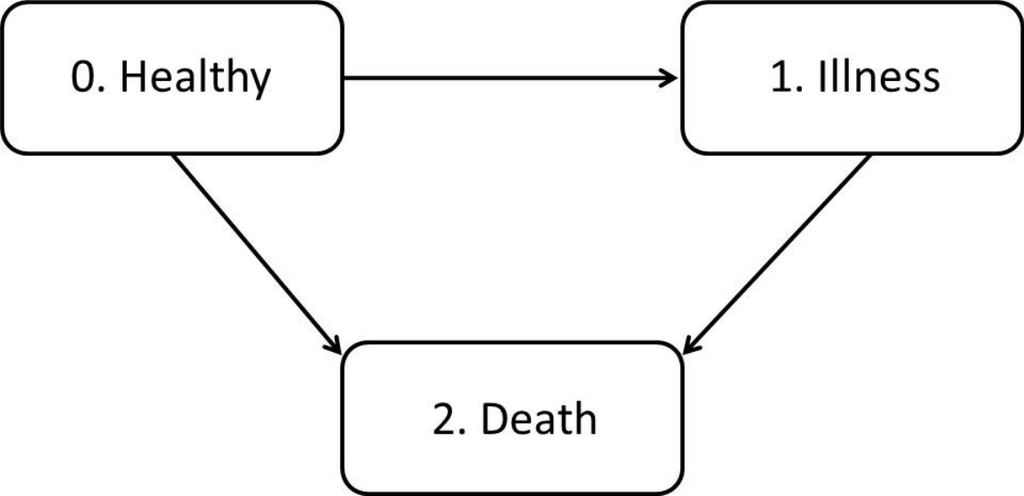

Figure 1: Progressive illness-death model.

One important goal in multi-state modeling is to relate the individual characteristics with the intensity rates through a covariate vector, but biomedical researchers are also interested in reporting interpretable results in a simple and summarized manner. These include estimates of predictive probabilities, such as the transition probabilities, occupation probabilities, cumulative incidence functions, and the sojourn time distributions. The development of [*survidm*](https://CRAN.R-project.org/package=survidm) R package has been motivated by several recent contributions that account for these problems; in particular the newly developed methods based on subsampling (see L. Meira-Machado and Sestelo (2019) for further details). The current version of the package provides seven different approaches to estimate the transition probabilities, two methods for the sojourn distributions and two approaches for the cumulative incidence functions. In addition, these probabilities can also be estimated conditionally on covariate measures. The package also allows the user to perform multi-state regression where the estimation of the covariate effects is achieved using Cox regression in which different effects of the covariates are assumed for different transitions.

Several researchers have recently developed software for multi-state survival analysis. A comprehensive list of the available packages in the Comprehensive R Archive Network (CRAN) can be seen in the CRAN task view ‘Survival Analysis’ (Allignol and Latouche 2018). In R, several packages provide functions for estimating the transition probabilities (e.g., the package [*p3state.msm*](https://CRAN.R-project.org/package=p3state.msm) (L. Meira-Machado and Roca-Pardiñas 2011), [*TPmsm*](https://CRAN.R-project.org/package=TPmsm) (Araújo, Roca-Pardiñas, and Meira-Machado 2014), [*etm*](https://CRAN.R-project.org/package=etm) (Allignol, Schumacher, and Beyersmann 2011), [*mstate*](https://CRAN.R-project.org/package=mstate) (Wreede, Fiocco, and Putter 2011), and [*TP.idm*](https://CRAN.R-project.org/package=TP.idm) (Balboa and Uña-Álvarez 2018)), but none implements all the methods addressed by [*survidm*](https://CRAN.R-project.org/package=survidm) which includes all newly developed methods based on the subsampling approach (see Uña-Álvarez and Meira-Machado (2015) and references therein). In addition, not all allow the users to obtain estimates of the transition probabilities conditional to covariates. The [*cmprsk*](https://CRAN.R-project.org/package=cmprsk) and the [*timereg*](https://CRAN.R-project.org/package=timereg) R packages can be used to estimate the cumulative incidence functions in a competing risks model. The package survival (via `survfit` and `coxph` functions) can also be used for competing risks data. The [*msSurv*](https://CRAN.R-project.org/package=msSurv) can be used to estimate the state occupation probabilities and the sojourn distributions for multi-state models subject to right-censoring (possibly state-dependent) and left-truncation. The package also provides matrices of transition probabilities between any two states. However, none of the available software provides an encompassing package which can be used to estimate all these quantities. Finally, the use of different packages for estimating these quantities separately is rather difficult because each of the current programs requests its own data structure. This paper introduces [*survidm*](https://CRAN.R-project.org/package=survidm) (available from the Comprehensive R Archive Network at https://cran.r-project.org/web/packages/survidm/), a software application for R which performs inference in a progressive illness-death model. It describes the capabilities of the program for estimating semiparametric regression models and for implementing nonparametric estimators for all quantities mentioned above.

The remainder of this paper is organized as follows. The following section provides a brief introduction to the methodological background. Then, a detailed description of the package is presented, and its usage is illustrated through the analysis of a real data set. Finally, the last section contains the main conclusions of this work.

# Methodology background

The mathematical background underlying the [*survidm*](https://CRAN.R-project.org/package=survidm) package is briefly introduced in this section. A more detailed introduction can be found in L. Meira-Machado and Sestelo (2019). The present contribution builds on this article by offering guidelines for using the software to implement the proposed methods.

## Notation

A multi-state model is a model for a time-continuous stochastic process $(Y(t),t\geq 0)$ which at any time occupies one of a few possible states. In this paper, we consider the progressive illness-death model depicted in Figure 1, and we assume that states are numbered as $0-healthy$, $1-illness$, and $2-death$. We also assume that all subjects enter the study in State 0 and that they may either visit State 1 at some time point; or not, going directly to the absorbing state (State 2).

This model is characterized by the joint distribution of $(Z,T)$, where $Z$ denotes the sojourn time in the initial State 0, and $T$ is the total survival time of the process. As usual with survival data, individuals are generally followed over a certain period of time, providing right-censored observations which are modeled by considering a censoring variable $C$, which we assume to be independent of of $(Z,T)$. Due to censoring, rather than $(Z,T)$, we observe $\widetilde Z=\min(Z,C)$, $\widetilde T=\min(T,C)$, $\Delta_1=I(Z\leq C)$, and $\Delta =I(T\leq C)$ for the respective censoring indicators of $Z$ and $T$. Finally, the available data is $(\widetilde Z_i,\widetilde T_i,\Delta_{1i},\Delta_i)$, $1\leq i\leq n$, i.i.d. copies of $(\widetilde Z,\widetilde T,\Delta_1,\Delta)$.

## Regression models for transitions intensities

One important goal in multi-state modeling is to study the relationships between the different predictors and the outcome. To relate the individual characteristics to the intensity rates, several models have been used in the literature. A common simplifying strategy is to decouple the whole process into various survival models by fitting separate intensities to all permitted transitions using semiparametric Cox proportional hazard regression models (Cox, 1972), while making appropriate adjustments to the risk set. The most common models are characterized through one of the two model assumptions that can be made about the dependence of the transition intensities and time. The transition intensities may be modeled using separated Cox models assuming the process to be Markovian (also known as the clock forward modeling approach), which states that past and future are independent given the present state. They can also be modeled using a semi-Markov model in which the future of the process does not depend on the current time but rather on the duration in the current state. Semi-Markov models are also called ‘clock reset’ models because each time the patient enters a new state, the time is reset to 0. The package [*survidm*](https://CRAN.R-project.org/package=survidm) is restricted to these two semiparametric multi-state models, but other models are possible for the analysis of multi-state survival data. For example, time-homogeneous markov models and model with piecewise constant intensities are implemented in the [*msm*](https://CRAN.R-project.org/package=msm) R package (Jackson 2011). Aalen additive model (O. O. Aalen, Borgan, and Fekjaer 2001) and accelerated failure time models (Wei 1992) are another class of regression models that can be an alternative to the Cox proportional hazards model.

## Transition probabilities

For two states $h$, $j$ and two time points $s < t$, the so-called transition probabilities $p_{hj}(s,t)=P(Y(t)=j|Y(s)=h)$ are introduced. In the progressive illness-death model, there are five different transition probabilities to estimate: $p_{00}(s,t)$, $p_{01}(s,t)$, $p_{02}(s,t)$, $p_{11}(s,t)$, and $p_{12}(s,t)$. Since $p_{00}(s,t)+p_{01}(s,t)+p_{02}(s,t)=1$ and $p_{11}(s,t)+p_{12}(s,t)=1$, in practice, one only needs to estimate three of these quantities. The state occupation probabilities are defined as $p_j(t)=P(Y(t)=j)$. If we assume that all subjects are in State 0 at time $t=0$, then $p_j(t)=p_{0j}(0,t)$ and, therefore, the occupation probabilities can be seen as a particular case of the transition probabilities. Estimating these quantities is interesting since they allow for long-term predictions of the process.

The standard nonparametric method to estimate a transition probability matrix is the time-honored Aalen-Johansen (`AJ`) estimator (O. Aalen and Johansen 1978). This estimator benefits from the assumption of Markovianity on the underlying stochastic process extending the time-honored Kaplan-Meier estimator (Kaplan and Meier 1958) to Markov chains. Explicit formulae of the Aalen-Johansen estimator for the illness-death model are available (Borgan 1988).

Moreira, Uña-Álvarez, and Meira-Machado (2013) propose a modification of the Aalen-Johansen estimator in the illness-death model based on a preliminary smoothing (also known as presmoothing, Dikta (1998; Cao et al. 2005)) of the censoring probability for the total time (respectively, of the sojourn time in State 0), given the available information. The presmoothed Aalen-Johansen (PAJ) estimator proposed by Moreira, Uña-Álvarez, and Meira-Machado (2013) is obtained by replacing the censoring indicators (in the transition probabilities $p_{00}(s, t)$ and $p_{11}(s, t)$) by an estimator of a binary (logistic) regression function. The authors verified through simulations that the use of presmoothing can lead to improved estimators with less variability.

The Markov assumption may be violated in practice. For example, for the progressive illness-death model, the arrival time to the intermediate state of the process often influences the subsequent transition hazard, leading to non-Markov structures. If the Markov property is violated, then the consistency of the time-honored Aalen-Johansen estimator and of its presmoothed versions can not be ensured in general. Exceptions to this are the estimators for $p_{00}(s, t)$ or for the so-called occupation probabilities, $p_{0j}(0, t)$ (Datta and Satten 2001).

Estimators for the transition probabilities in the progressive illness-death model, which do not rely on the Markov assumption, were introduced for the first time by L. Meira-Machado, de Uña-Álvarez, and Cadarso-Suárez (2006). The proposed estimators were defined in terms of multivariate Kaplan-Meier integrals with respect to the marginal distributions of $Z$ and $T$. These authors showed the practical superiority of their estimators relative to the Aalen-Johansen in situations in which the Markov condition is strongly violated. However, their proposal has the drawback of requiring that the support of the censoring distribution contains the support of the lifetime distribution. Otherwise, they only report valid estimators for truncated transition probabilities. To avoid this issue, corrected estimators (labeled in this paper as `LIDA`, the acronym of Lifetime Data Analysis, the journal in which this estimator was published for the first time) were proposed by Uña-Álvarez and Meira-Machado (2015) for $p_{01}(s,t)$ and $p_{11}(s,t)$.

The paper by Uña-Álvarez and Meira-Machado (2015) also introduces estimators based on subsampling. The idea behind subsampling, also referred to as landmarking (Van Houwelingen 2007), is to consider the subset of individuals observed in State $h$ by time $s$. To be specific, given the time point $s$, to estimate $p_{0j}(s,t)$ for $j=0,1,2,$ the landmark analysis is restricted to the individuals observed in State 0 at time $s$. Whereas, to estimate $p_{1j}(s,t)$, $j=1,2$, the landmark analysis proceeds from the sample restricted to the individuals observed in State 1 at time $s$. The procedure is then based on (differences between) Kaplan-Meier estimators derived from these subsets of the data. These estimators are termed `LM` in the present paper as well as in the [*survidm*](https://CRAN.R-project.org/package=survidm) package.

In some cases, subsampling leads to small sample sizes which may result in estimators with high variability. To avoid this problem, a valid approach is to consider a modification of the landmark estimator based on presmoothing (Luis Meira-Machado 2016). The presmoothed landmark estimators (`PLM`) are a good alternative in these situations since they give mass to all the event times, including the censored observations.

Subsampling was later used by H. Putter and Spitoni (2018) to derive a landmark Aalen-Johansen estimator (`LMAJ`) of the transition probabilities. The idea behind the proposed estimator is to use the Aalen-Johansen estimator of the state occupation probabilities derived from those subsets (consisting of subjects occupying a given state at a particular time) for which consistency have already been proved in multi-state models that are not necessarily Markov (Datta and Satten 2001). In this latter approach, the application of presmoothed estimators (`PLMAJ`) is possible too.

Also of interest is the estimation of the transition probabilities given a covariate (or a vector of covariates) that is observed for an individual before the individual makes a particular transition of interest. One standard method, particularly well-suited to the setting with multiple covariates, is to consider estimators based on a Cox’s regression model (Cox 1972) fitted marginally to each transition with the corresponding baseline hazard function estimated by the Breslow’s method (Breslow 1972). One alternative and flexible nonparametric approach is to consider local smoothing by means of kernel weights based on local constant (Nadaraya-Watson) regression. Right censoring is handled by applying inverse probability of censoring weighting. This is a fully nonparametric approach which provides flexible effects of the continuous covariates (L. Meira-Machado, Uña-Álvarez, and Datta 2015; Rodríguez-Álvarez, Meira-Machado, and Abu-Assi 2016; L. Meira-Machado and Sestelo 2019). The two possible approaches are implemented in the [*survidm*](https://CRAN.R-project.org/package=survidm) package and labeled as `breslow` and `IPCW`, respectively.

## Cumulative incidence functions

Another quantity of interest in multi-state modeling is the cause-specific cumulative incidence function, as defined by Kalbfleisch and Prentice (1980). In the illness-death model, two cumulative incidence functions are of particular interest: the cumulative incidence of the illness and the cumulative incidence of dying without the disease. These quantity represents the probability of an individual being or having been diseased at time $t$. One possible estimator for the cause-specific cumulative incidence function in a competing risks setting can be performed using the estimator proposed by (Geskus 2011). This estimator based on the subdistribution hazard is obtained by applying the Nelson-Aalen estimator and the product-limit estimator of the disease-free survival. This estimator can also be expressed in terms of the Kaplan-Meier weights of the distribution of $Z$, the sojourn time in State 0, as introduced in the paper by L. Meira-Machado and Sestelo (2019). A modification of this estimator based on presmoothing can be introduced to reduce its variability. Both methods are implemented in the [*survidm*](https://CRAN.R-project.org/package=survidm) package. Estimation methods for the cumulative incidence function conditionally on covariate measures based on local constant (Nadaraya-Watson) regression are also implemented in the package.

## Sojourn distributions

The estimation of the marginal distributions in multi-state modeling is an interesting topic too. In the context of the illness-death model, if the independence assumption between the censoring variable $C$ and the vector of times $(Z,T)$ is assumed, the marginal distribution of the sojourn time in State 0, $Z$, can be consistently estimated by the Kaplan-Meier estimator based on the $(\widetilde Z_i, \Delta_{1i})$’s. Similarly, the distribution of the total time may be consistently estimated by the Kaplan-Meier estimator based on the $(\widetilde T_i, \Delta_{i})$’s. However, the estimation of the marginal distribution of the sojourn time in State 1 is not such a simple issue. Nonparametric estimates for this marginal distribution allowing for state and path-dependent censoring were proposed by Satten and Datta (2002).

# *survidm* in practice

This section introduces an overview of how the package is structured.

Table 1: Summary of functions in the *survidm* package.

| Function | Description |
| --- | --- |
| `survIDM` | Create a `survIDM` object. |
| `coxidm` | Fits proportional hazards regression models for each transition. |
| `tprob` | Estimation of the transition probabilities. |
| `CIF` | Estimation of the cumulative incidence functions. |
| `sojourn` | Nonparametric estimation of the sojourn distribution in the intermediate state. |
| `autoplot.survIDM` | Visualization of `survIDM` objects with [*ggplot2*](https://CRAN.R-project.org/package=ggplot2) and [*plotly*](https://CRAN.R-project.org/package=plotly) graphics. |
| `plot.survIDM` | Plot for an object of class `survIDM`. |
| `print.survIDM` | Print for an object of class `survIDM`. |
| `summary.survIDM` | Summary for an object of class `survIDM`. |
| `nevents` | Counts the number of observed transitions in the multi-state model. |
| `markov.test` | Performs a test for the Markov assumption. |
| `KM` | Computes the Kaplan-Meier product-limit of survival. |
| `PKM` | Computes the presmoothed Kaplan-Meier product-limit of survival. |
| `Beran` | Computes the conditional survival probability of the response, given the covariate under random censoring. |
| `KMW` | Returns a vector with the Kaplan-Meier weights. |
| `PKMW` | Returns a vector with the presmoothed Kaplan-Meier weights. |
| `LLW` | Returns a vector with the local linear weights. |
| `NWW` | Returns a vector with the Nadaraya-Watson weights. |

It should be noted that to implement the methods described in the methodology section, one needs the following variables of data: `time1`, `event1`, `Stime`, and `event`. Covariates can also be included. The variable `time1` represents the sojourn time in State 0 and `Stime` the total time, whereas `event1` and `event` are the respective censoring indicators. This means that `event1` will take the value 1 if the subject leaves State 0 and 0 otherwise; `event` takes value 1 if the subject reaches State 2 and 0 otherwise.

For illustration, we apply the proposed methods to data from a large clinical trial on Duke’s stage III patients affected by colon cancer that underwent a curative surgery for colorectal cancer (Moertel et al. 1990). This data set is freely available as part of the R [*survival*](https://CRAN.R-project.org/package=survival) package. The data is also available as part of the R package [*survidm*](https://CRAN.R-project.org/package=survidm). Besides the two event times (disease-free survival time and death time) and the corresponding indicator statuses, a vector of covariates including rx (treatment: Obs(ervation), Lev(amisole), Lev(amisole)+5FU), sex (1 - male), age (years), nodes (number of lymph nodes with detectable cancer), surge (time from surgery to registration: 0 = short, 1 = long), adhere (adherence to nearby organs) are also available. The covariate ‘recurrence’ is the only time-dependent covariate, while the other covariates included are fixed. Recurrence can be considered as an intermediate transient state and modeled using the progressive illness-death model with transient states ‘alive and disease-free’ and ‘alive with recurrence’, and the absorbing state ‘dead’. In the following, we will demonstrate the package capabilities using this data. Below is an excerpt of the data.frame with one row per individual. Individuals were chosen in order to represent all possible combinations of movements among the three states.

```r
> library("survidm")
> data(colonIDM)
> colonIDM[c(1:2,16,21),1:7]

   time1 event1 Stime event      rx sex age
1    968      1  1521     1 Lev+5FU   1  43
2   3087      0  3087     0 Lev+5FU   1  63
16  1323      1  3214     0     Obs   1  68
21  2789      1  2789     1     Obs   1  64
```

Of the total of 929 patients, 468 developed a recurrence, and among these 414 died, 38 patients died without developing a recurrence. A summary of the data with the number of the undergoing transitions can be obtained through the `nevents` function. The colums of the data set must include at least the four columns named `time1`, `event1`, `Stime`, and `event` according to the requirements of the `survIDM` function presented in the help file. Parameter `state.names` enables to change the default values of states, ‘healthy’, ‘illness’, and ‘death’.

```r
> nevents(with(colonIDM, survIDM(time1, event1, Stime, event)),
          state.names = c("healthy", "recurrence", "death"))

           healthy recurrence death
healthy        423        468    38
recurrence       0         54   414
death            0          0   452
```

## Regression models for transitions intensities

To relate the individual characteristics to the intensity rates, semiparametric multi-state regression models are used. Specifically, separated Cox models assuming the process to be Markovian (i.e., the transition intensities only depend on the history of the process through the current state) or using a semi-Markov model in which the future of the process does not depend on the current time but rather on the duration in the current state. Therefore, practical interest to determine whether the Markov property holds within a particular data set to determine whether a Markov model or a semi-Markov model is more appropriate.

### The Markov assumption

The Markov assumption may be checked, among others, by including covariates depending on the history. For the progressive illness-death model, the Markov assumption is only relevant for mortality transition after recurrence. We can examine whether the time spent in the initial state "Alive and disease-free" (i.e., the past) is important in the transition from the recurrence state to death (i.e., the future). For doing that, let $Z$ be the time spent in State 0 and $t$ the current time. Fitting a model $\alpha_{12} (t; Z) = \alpha_{12,0} (t) exp\{\beta Z\}$, we now need to test the null hypothesis, $H_0 : \beta=0$, against the general alternative, $H_1 : \beta \neq 0$. This would assess the assumption that the transition rate from the disease state into death is unaffected by the time spent in the previous state.

```r
> library(survival)
> fit <- coxph(Surv(time1, Stime, event) ~ time1, data = colonIDM,
               subset=c(time1 < Stime))
> fit
            coef  exp(coef)   se(coef)      z     p
time1 -0.0002475  0.9997526  0.0001737 -1.424 0.154

Likelihood ratio test=2.04  on 1 df, p=0.1533
n= 468, number of events= 414
```

Following this procedure, we verified that the effect of time spent in State 0 reported a *p*-value of 0.154 (regression coefficient: - 0.0002475), revealing no evidence against the Markov model for the colon data. Results from this test can also be obtained through the function `markov.test`, which has an output fairly similar to those obtained from `coxph` function.

```r
> mk <- markov.test(survIDM(time1, event1, Stime, event) ~ 1, data = colonIDM)
> mk
```

[output not shown]

Since there is no evidence on the lack of Markovianity, a multi-state Markov regression model based on the Cox model can be fitted through the following input command:

```r
> fit.cmm <- coxidm(survIDM(time1, event1, Stime, event) ~ rx + sex + age +
                    nodes + surg + adhere, data = colonIDM)

> summary(fit.cmm)

Cox Markov Model: transition 0 -> 1

                  coef exp(coef) lower 0.95 upper 0.95     Pr(>|z|)
rxLev     -0.061251858 0.9405863  0.7596976  1.1645457 5.740592e-01
rxLev+5FU -0.515170844 0.5973985  0.4713678  0.7571264 2.031682e-05
sex       -0.149177218 0.8614164  0.7160077  1.0363552 1.137849e-01
age       -0.004669254 0.9953416  0.9876802  1.0030625 2.362711e-01
nodes      0.083943790 1.0875678  1.0686993  1.1067694 5.418662e-21
surg       0.251798521 1.2863368  1.0509673  1.5744186 1.460249e-02
adhere     0.296839791 1.3455997  1.0551768  1.7159575 1.671466e-02


Cox Markov Model: transition 0 -> 2

                 coef exp(coef) lower 0.95 upper 0.95     Pr(>|z|)
rxLev     -0.29152482 0.7471235  0.3271685   1.706135 4.889711e-01
rxLev+5FU -0.11211853 0.8939383  0.4220165   1.893589 7.697006e-01
sex        0.39293182 1.4813174  0.7641923   2.871399 2.445966e-01
age        0.08422764 1.0878765  1.0476871   1.129608 1.157046e-05
nodes      0.07538428 1.0782984  0.9895116   1.175052 8.552937e-02
surg       0.41564547 1.5153485  0.7703441   2.980851 2.285509e-01
adhere     0.05435239 1.0558566  0.4377875   2.546517 9.036879e-01


Cox Markov Model: transition 1 -> 2

                  coef exp(coef) lower 0.95 upper 0.95     Pr(>|z|)
rxLev      0.068953592  1.071386  0.8533466   1.345138 5.525534e-01
rxLev+5FU  0.327043851  1.386862  1.0741245   1.790656 1.212756e-02
sex        0.214094887  1.238740  1.0138220   1.513557 3.623833e-02
age        0.009342474  1.009386  1.0014760   1.017359 1.994502e-02
nodes      0.046061552  1.047139  1.0249376   1.069821 2.522475e-05
surg      -0.012258877  0.987816  0.7944594   1.228232 9.121722e-01
adhere     0.137708158  1.147641  0.8851963   1.487895 2.985854e-01
```

The transition intensities characterize the hazard for movement from one state to another, revealing how the different covariates affect the various permitted transitions. The results obtained indicate that none of the covariates were found to have a strong effect on all three transitions. Save for covariates age and sex, all the remaining predictors were considered important for recurrence transition. Interestingly, age displayed a strong linear effect on mortality transition without recurrence, whereas all the other covariates failed to show relevant association on this transition. Finally, save for covariates surg and adhere, all the remaining predictors were considered important for the mortality transition after recurrence. The `coxidm` function also returns the analysis of the deviance for each Cox model. In this case, only an overall *p*-value is presented for categorical variables. To obtain the outputs, we have to indicate `type`=‘anova’ in `summary` function.

```r
> summary(fit.cmm,type = 'anova')

Cox Markov Model: transition 0 -> 1

        loglik   Chisq Df Pr(>|Chi|)
NULL   -2954.2
rx     -2941.8 24.6964  2  4.338e-06 ***
sex    -2941.0  1.6402  1    0.20030
age    -2939.8  2.3435  1    0.12581
nodes  -2909.0 61.6050  1  4.198e-15 ***
surg   -2906.2  5.7134  1    0.01684 *
adhere -2903.5  5.3740  1    0.02044 *
---
Signif. codes:  0 ‘***’ 0.001 ‘**’ 0.01 ‘*’ 0.05 ‘.’ 0.1 ‘ ’ 1


Cox Markov Model: transition 0 -> 2


        loglik   Chisq Df Pr(>|Chi|)
NULL   -231.79
rx     -231.54  0.4938  2     0.7812
sex    -231.04  1.0065  1     0.3158
age    -219.26 23.5445  1  1.221e-06 ***
nodes  -218.04  2.4536  1     0.1173
surg   -217.35  1.3830  1     0.2396
adhere -217.34  0.0145  1     0.9043
---
Signif. codes:  0 ‘***’ 0.001 ‘**’ 0.01 ‘*’ 0.05 ‘.’ 0.1 ‘ ’ 1


Cox Markov Model: transition 1 -> 2


        loglik   Chisq Df Pr(>|Chi|)
NULL   -1897.5
rx     -1895.0  4.8864  2  0.0868804 .
sex    -1892.8  4.3995  1  0.0359501 *
age    -1890.8  4.0650  1  0.0437799 *
nodes  -1883.4 14.7205  1  0.0001247 ***
surg   -1883.4  0.0090  1  0.9242629
adhere -1882.9  1.0505  1  0.3054007
---
Signif. codes:  0 ‘***’ 0.001 ‘**’ 0.01 ‘*’ 0.05 ‘.’ 0.1 ‘ ’ 1
```

The effect of the continuous covariates on the log hazards is often assumed to have a linear functional form in all intensities. To introduce flexibility into the Cox Markov model, several smoothing methods may be applied, but P-splines (Eilers and Marx 1996) are being most frequently considered in this context. Results showed a strong nonlinear effect for nodes (checked through a formal test) when using a Cox model on the recurrence transition. Figure 2 returns a centered set of predictions on a log hazard scale. The average predicted value is zero with a mean value of nodes as the reference (see the vignette ‘Splines, plots, and interactions’ in (Therneau 2021)). The main curve depicts the smooth curve for nodes on a log hazard scale, indicating that the risk of recurrence increases rapidly until about 6 nodes. The apparent decrease after 23 nodes is not significant due to the wide confidence intervals.

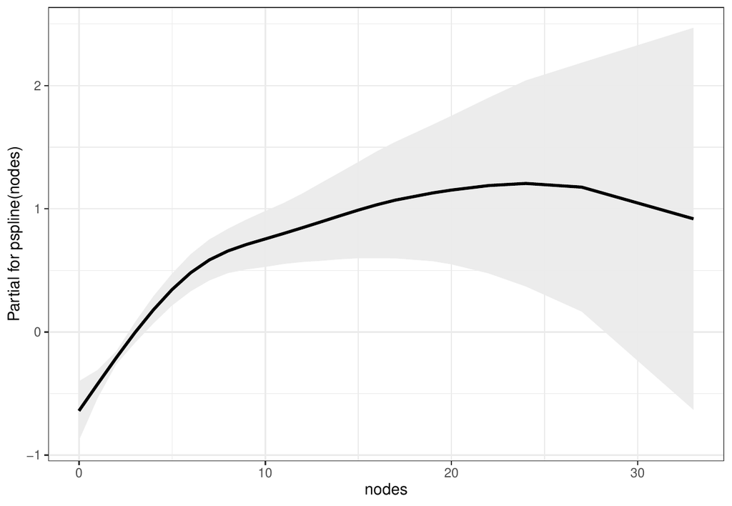

Figure 2: Predicted values of the smooth log hazard based on penalized splines (black line) with pointwise 95% confidence intervals obtained from the partial residuals for nodes (recurrence intensity), using the colon cancer data.

```r
> library(ggplot2)
> library(plotly)

> fit2.cmm <- coxidm(survIDM(time1, event1, Stime, event) ~ rx + sex + age +
                  pspline(nodes) + surg + adhere, data = colonIDM)


> d<-data.frame(x=fit2.cmm$term01$nodes$x, y=fit2.cmm$term01$nodes$y,
                y1=fit2.cmm$term01$nodes$y-1.96*fit2.cmm$term01$nodes$se,
                y2=fit2.cmm$term01$nodes$y+1.96*fit2.cmm$term01$nodes$se)

> nonlinear<-ggplot(d, aes(x,y))+theme(axis.text=element_text(size=13))+
             theme_bw()+labs(x = "nodes") +
             labs(y = "Partial for pspline(nodes)")+
             geom_ribbon(aes(ymin=y1,ymax=y2),fill='gray92',alpha=0.9)+
             geom_line(aes(x,y))+
             geom_line(color=1,size=1)

> ggplotly(nonlinear)
```

The proportional hazards assumption can be tested formally using the `summary` function. The output can be obtained putting `type=’ph’` in `summary` function.

```r
> summary(fit2.cmm, type = 'ph')

Cox Markov Model: transition 0 -> 1
Test the Proportional Hazards Assumption

                  chisq   df    p
rx             4.12e-01 2.00 0.81
sex            2.10e+00 1.00 0.15
age            9.37e-04 1.00 0.98
pspline(nodes) 7.60e+00 3.95 0.10
surg           1.97e+00 1.00 0.16
adhere         6.13e-01 1.00 0.43
GLOBAL         1.30e+01 9.94 0.22


Cox Markov Model: transition 0 -> 2
Test the Proportional Hazards Assumption

                chisq   df    p
rx             1.6292 2.00 0.44
sex            0.0668 1.00 0.80
age            0.8396 1.00 0.36
pspline(nodes) 0.7859 4.00 0.94
surg           0.4955 1.00 0.48
adhere         2.3606 1.00 0.12
GLOBAL         6.1424 9.99 0.80


Cox Markov Model: transition 1 -> 2
Test the Proportional Hazards Assumption

                  chisq    df    p
rx              5.03913  1.99 0.08
sex             0.02204  1.00 0.88
age             0.73628  1.00 0.39
pspline(nodes)  4.25500  4.09 0.39
surg            2.02427  1.00 0.15
adhere          0.00177  1.00 0.97
GLOBAL         13.19170 10.08 0.22
```

A semi-Markov model could be obtained by including the argument `semiMarkov = TRUE` in the `coxidm` function.

## Occupation probabilities and transition probabilities

The occupation probabilities and the transition probabilities are key quantities of interest in multi-state models. They offer interpretable results in a simple and summarized manner.

Estimates and plots of the transition probabilities for all methods introduced in Section 2 can be obtained using the `tprob` function. The default method is the Aalen-Johansen estimator (`AJ`) which assumes the process to be Markovian. The presmoothed version of the Aalen-Johansen estimator (`PAJ`) also assumes the process to be Markovian while the remaining methods (`LIDA`, `LM`, `PLM`, `LMAJ`, and `PLMAJ`) are free of the Markov condition.

When one is confident of the Markov assumption, the Aalen-Johansen is preferred over the non-Markovian estimators since it reports a smaller variance in estimation. Estimates and plot for the Aalen-Johansen method can be obtained through the following input commands:

```r
> tpAJ <- tprob(survIDM(time1, event1, Stime, event) ~ 1, s = 365,
                method = "AJ", conf = TRUE, data = colonIDM)

> summary(tpAJ, times=365*2:6)

Estimation of pij(s=365,t)

    t        00        01        02        11        12
  730 0.7966309 0.1300071 0.0733620 0.4686360 0.5313640
 1095 0.7192603 0.1224599 0.1582799 0.2533822 0.7466178
 1460 0.6805333 0.0884287 0.2310380 0.1335300 0.8664700
 1825 0.6444157 0.0859123 0.2696720 0.0932851 0.9067149
 2190 0.6131533 0.0774912 0.3093556 0.0632835 0.9367165

2.5%

    t        00        01        02        11        12
  730 0.7673408 0.1093487 0.0589350 0.4105298 0.4728114
 1095 0.6867036 0.1026150 0.1354061 0.2105314 0.7011204
 1460 0.6468259 0.0714743 0.2030840 0.1047501 0.8346547
 1825 0.6098804 0.0688614 0.2396632 0.0708282 0.8813846
 2190 0.5780541 0.0612090 0.2777007 0.0464018 0.9172849

97.5%

    t        00        01        02        11        12
  730 0.8270390 0.1545683 0.0913208 0.5349666 0.5971676
 1095 0.7533604 0.1461425 0.1850177 0.3049547 0.7950677
 1460 0.7159973 0.1094050 0.2628397 0.1702170 0.8994981
 1825 0.6809066 0.1071852 0.3034384 0.1228620 0.9327733
 2190 0.6503836 0.0981045 0.3446188 0.0863070 0.9565597

> autoplot(tpAJ)
```

Besides being consistent regardless the Markov condition, the landmark non-Markov estimators (`LM`, `PLM`, `LMAJ`, and `PLMAJ`) can be preferable in many situations due to their greater accuracy (smaller bias). When comparing the original nonparametric landmark estimator (`LM`) and the Aalen-Johansen estimator, some discrepancies are observed for $t=730$ and $t=1095$ (2 and 3 years, respectively). In addition to the aforementioned discrepancy between the two estimates, the plots for the two methods (Figure 3) also show that the confidence bands are narrower in the case of the Aalen-Johansen, revealing less variability for this method.

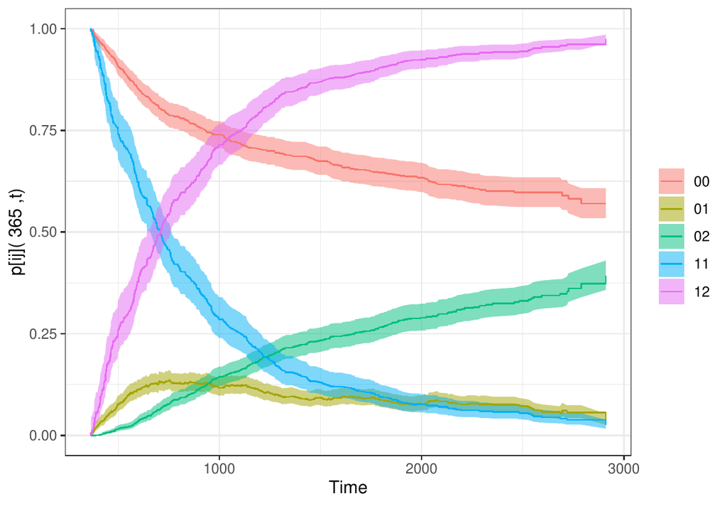

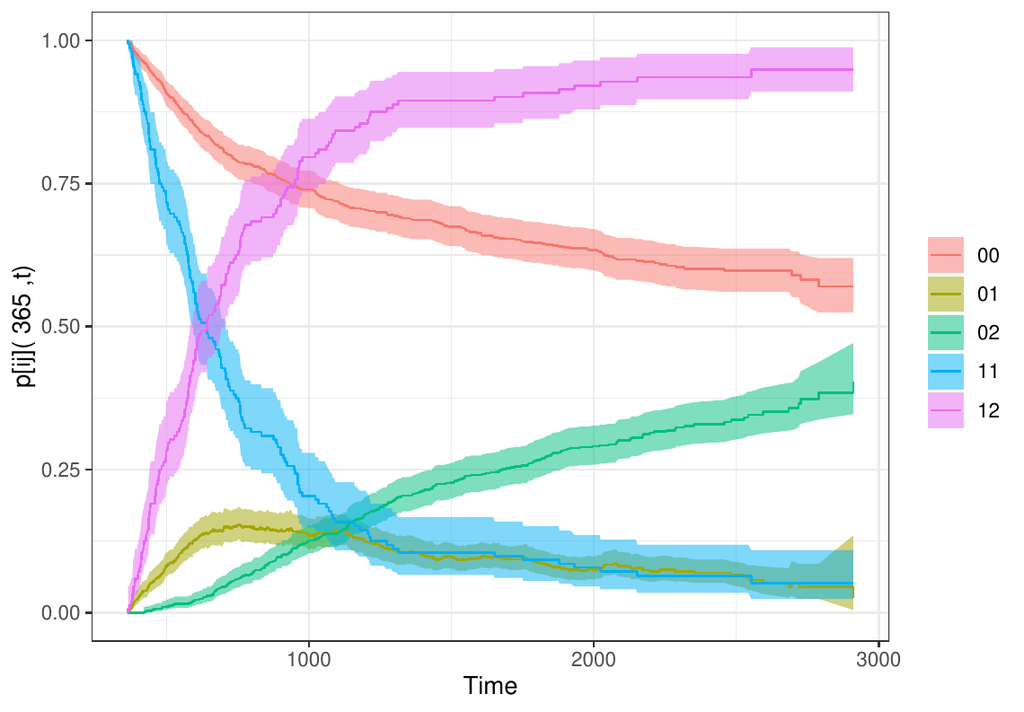

Figure 3: Transition probability estimates using the `AJ` (left hand side) and `LM` (right hand side) method, using the colon cancer data.

```r
> tpLM <- tprob(survIDM(time1, event1, Stime, event) ~ 1, s = 365,
               method = "LM", conf = TRUE, data = colonIDM)

> summary(tpLM, times=365*2:6)

Estimation of pij(s=365,t)

    t        00         01        02         11        12
  730 0.7966309 0.14750103 0.0558681 0.38815789 0.6118421
 1095 0.7192603 0.14320925 0.1375305 0.15789474 0.8421053
 1460 0.6805333 0.09446864 0.2249981 0.10526316 0.8947368
 1825 0.6444157 0.08583643 0.2697479 0.09210526 0.9078947
 2190 0.6131533 0.07465238 0.3121944 0.06432749 0.9356725

2.5%

    t        00         01        02         11        12
  730 0.7673274 0.12294665 0.0411836 0.31792669 0.5390734
 1095 0.6866872 0.12033558 0.1142137 0.10937624 0.7860868
 1460 0.6468058 0.07447488 0.1960521 0.06621973 0.8472552
 1825 0.6098421 0.06804756 0.2387239 0.05591405 0.8630680
 2190 0.5777125 0.05742370 0.2791810 0.03480413 0.8969820

97.5%

    t        00         01         02        11        12
  730 0.8270534 0.17695930 0.07578852 0.4739034 0.6944337
 1095 0.7533784 0.17043081 0.16560740 0.2279357 0.9021157
 1460 0.7160195 0.11982998 0.25821767 0.1673268 0.9448794
 1825 0.6809493 0.10827565 0.30480372 0.1517218 0.9550498
 2190 0.6507682 0.09705015 0.34911161 0.1188947 0.9760319

> autoplot(tpLM)
```

Since the landmark estimators of the transition probabilities are free of the Markov assumption, they can also be used to introduce such tests (at least in the scope of the illness-death model) by measuring their discrepancy to Markovian estimators. The function `markov.test` performs a local graphical test for the Markov condition. This graphical test is based on a PP-plot which compares the estimations reported by the Aalen-Johansen transition probabilities to their non-Markov counterparts. The corresponding plot for a local test of Markovianity ($s=365$) can be obtained through the following input command:

```r
> mk <- markov.test(survIDM(time1, event1, Stime, event) ~ 1, s = 365, data = colonIDM)
> autoplot(mk)
```

The plot shown in Figure 4 compares the Aalen-Johansen estimator and the landmark non-Markovian estimator for $p_{01}(s, t)$, $p_{02}(s, t)$, and $p_{12}(s, t)$, for $s = 365$. Existing deviations of the plots with respect to the straight line $y = x$ reveals some evidence on the lack of Markovianity of the underlying process beyond one year after surgery. For further illustration, this figure jointly displays the landmark non-Markovian estimator and the Aalen-Johansen estimator for $p_{12}(s=365, t)$. In this plot, the differences between both estimators are clearly seen. Thus, in principle, the application of the Aalen-Johansen method is not recommended here due to possible biases.

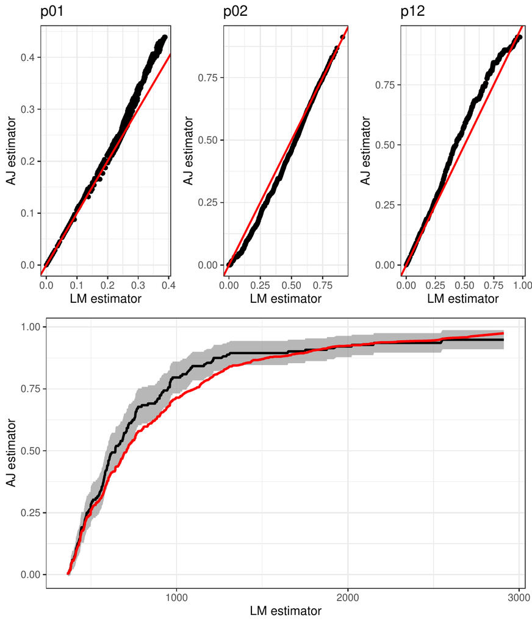

Figure 4: Graphical test for the Markov condition, $s = 365$. The second row shows the landmark (Markov-free) estimator with 95% pointwise confidence limits (black line) and Aalen-Johansen estimator (red line) for the transition probability $p_{12}(365, t)$, using the colon cancer data.

The variability of the nonparametric landmark estimator (`LM`) may be successfully reduced using presmoothing ideas (Dikta 1998; Cao et al. 2005). The presmoothed landmark estimator is implemented in the same function through the method `PLM`. The same ideas can be used to reduce the variability of the Markovian Aalen-Johansen estimator and the (non-Markov) Landmark Aalen-Johansen estimator through methods `PAJ` and `PLMAJ`, respectively.

The package [*survidm*](https://CRAN.R-project.org/package=survidm) also allows for the computation of the above quantities conditional on covariates that are observed for an individual before the individual makes a particular transition of interest. For continuous covariates, one possible and flexible nonparametric approach is to consider local smoothing by means of kernel weights based on local constant (Nadaraya-Watson: `NW`) regression. This estimator is implemented in our package through function `tprob` using the `method = IPCW`. Below are the input commands to obtain the estimates of the transition probabilities at time $s=365$ for an individual of 48 years old. For the bandwidth in the estimator, we use `dpik` function, which is available from the R [*KernSmooth*](https://CRAN.R-project.org/package=KernSmooth) package. This is the data-based bandwidth selector of Wand and Jones (1997).

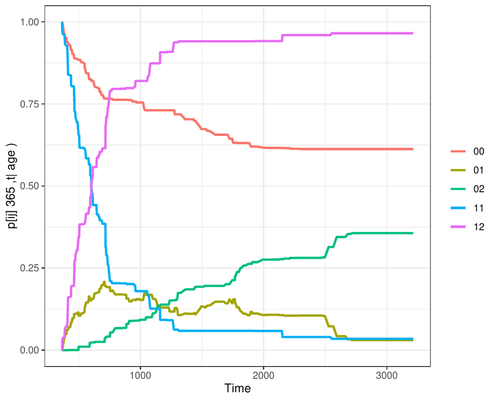

Figure 5: Conditional transition probabilities given that the subject is alive and disease-free at $s=365$ days for a 48-years-old patient, using the colon cancer data.

```r
> tpIPCW.age <- tprob(survIDM(time1, event1, Stime, event) ~ age, s = 365,
                method = "IPCW", z.value = 48, conf = FALSE, data = colonIDM,
                bw = "dpik", window = "gaussian", method.weights = "NW")

> summary(tpIPCW.age, time=365*2:6)

Estimation of pij(s=365,t)

    t        00        01         02         11        12
  730 0.7662208 0.1921290 0.04165012 0.28946129 0.7105387
 1095 0.7308496 0.1688189 0.10033149 0.12631010 0.8736899
 1460 0.6980293 0.1088373 0.19313342 0.05905711 0.9409429
 1825 0.6310625 0.1186104 0.25032706 0.05903929 0.9409607
 2190 0.6157095 0.1051797 0.27911080 0.04035816 0.9596418

> autoplot(tpIPCW.age)
```

The curves depicted in Figure 5, which are purely nonparametric, enable flexible modeling of the data providing flexible and robust effects of the covariate that can be used at least as a preliminary attempt, providing insights on the data being analyzed. Such methods can be used to capture nonstandard data features that may not be detected through parametric or semiparametric proposals. A general problem in multivariate nonparametric regression estimation is the so-called curse of dimensionality. In higher dimensions, the observations are sparsely distributed even for large sample sizes. Consequently, estimators based on local averaging (like those based on kernel smoothing) perform unsatisfactorily in this situation.

An alternative method is to consider estimators based on Cox’s regression model (Cox 1972) fitted marginally to each transition with the corresponding baseline hazard function estimated by Breslow’s method (Breslow 1972). The following input commands illustrate the use of the `tprob` function in this context:

```r
> tp.breslow.age <- tprob(survIDM(time1, event1, Stime, event) ~ age, s = 365,
                    method = "breslow", z.value = 48, conf = FALSE, data = colonIDM)

> summary(tp.breslow.age, time=365*2:6)

Estimation of pij(s=365,t)

    t        00         01         02         11        12
  730 0.7970855 0.15020199 0.05271253 0.37528949 0.6247105
 1095 0.7198657 0.14999685 0.13013746 0.14814634 0.8518537
 1460 0.6826444 0.10384005 0.21351550 0.09843946 0.9015605
 1825 0.6451532 0.09850122 0.25634562 0.08617378 0.9138262
 2190 0.6139465 0.08891388 0.29713961 0.06066618 0.9393338
```

Note that if the argument `z.value` is missing, then the `tprob` function computes the predicted conditional transition probabilities at the average values of the covariate. The Breslow method (based on the Cox regression model) is particularly well-suited to the setting with multiple covariates:

```r
> tp.breslow <- tprob(survIDM(time1, event1, Stime, event) ~ rx + age + nodes, s = 365,
                method = "breslow", z.value = c('Obs', 50, 10), conf = FALSE,
                data = colonIDM)

> summary(tp.breslow, time=365*2:6)

Estimation of pij(s=365,t)

    t        00        01        02         11        12
  730 0.6423398 0.24905912 0.1086010 0.30017412 0.6998259
 1095 0.5222992 0.21890332 0.2587975 0.09465150 0.9053485
 1460 0.4680828 0.12787851 0.4040387 0.05433167 0.9456683
 1825 0.4181094 0.10712224 0.4747684 0.04519157 0.9548084
 2190 0.3762996 0.08424903 0.5394514 0.02685212 0.9731479
```

## Cumulative Incidence Function

Another quantity of interest in multi-state modeling is the cause-specific cumulative incidence of the illness (recurrence). Function `CIF` can be used to obtain the nonparametric estimator of Geskus (2011) (default method), which is equivalent to the classical Aalen-Johansen estimator. The corresponding presmoothed version (Meira-Machado and Sestelo, 2018) is also implemented through the argument `presmooth = TRUE`:

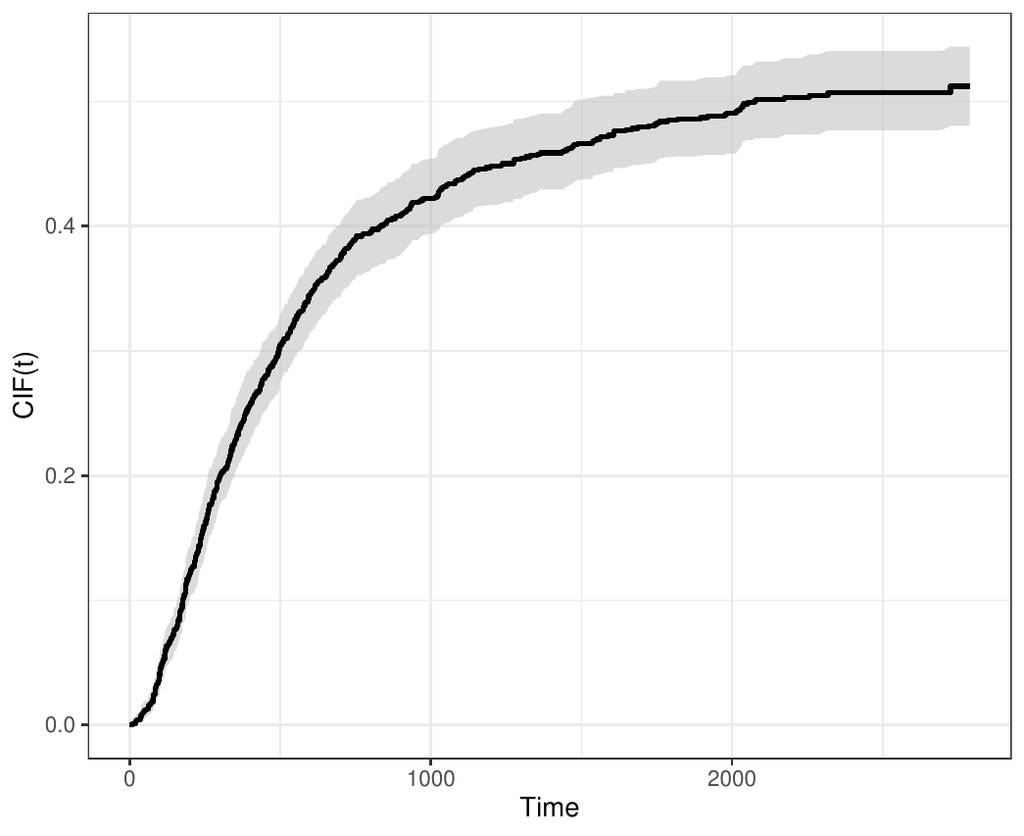

Figure 6: Cumulative incidence function in the recurrence state with 95% bootstrap confidence bands, using the colon cancer data.

```r
> cif <- CIF(survIDM(time1, event1, Stime, event) ~ 1, data = colonIDM, conf = TRUE)
> summary(cif, time=365*1:6)

Estimation of CIF(t)
    t       CIF
  365 0.2378902
  730 0.3844412
 1095 0.4372663
 1460 0.4620841
 1825 0.4859813
 2190 0.5032043

2.5%

    t       CIF
  365 0.2088267
  730 0.3509039
 1095 0.4038141
 1460 0.4296740
 1825 0.4540347
 2190 0.4697608

97.5%

    t       CIF
  365 0.2616792
  730 0.4103338
 1095 0.4666664
 1460 0.4900876
 1825 0.5161684
 2190 0.5319749

> autoplot(cif, ylim=c(0, 0.6), confcol = 2)
```

Figure 6 depicts the estimates of cumulative incidence function for the recurrent state together with a 95% pointwise confidence bands based on simple bootstrap that resamples each datum with probability $1/n$. From this plot, it can be seen that individuals have a probability of recurrence higher than 50%. This cumulative probability is about 43% at three years after surgery.

Figure 7 depicts the estimates of the (conditional) cumulative incidence function for patients with 1 and 9 lymph nodes with detectable cancer. Curves depicted in this figure, which are purely nonparametric, indicate that patients with 9 lymph nodes with detectable cancer have a considerably higher probability of recurrence. The corresponding input commands are shown below:

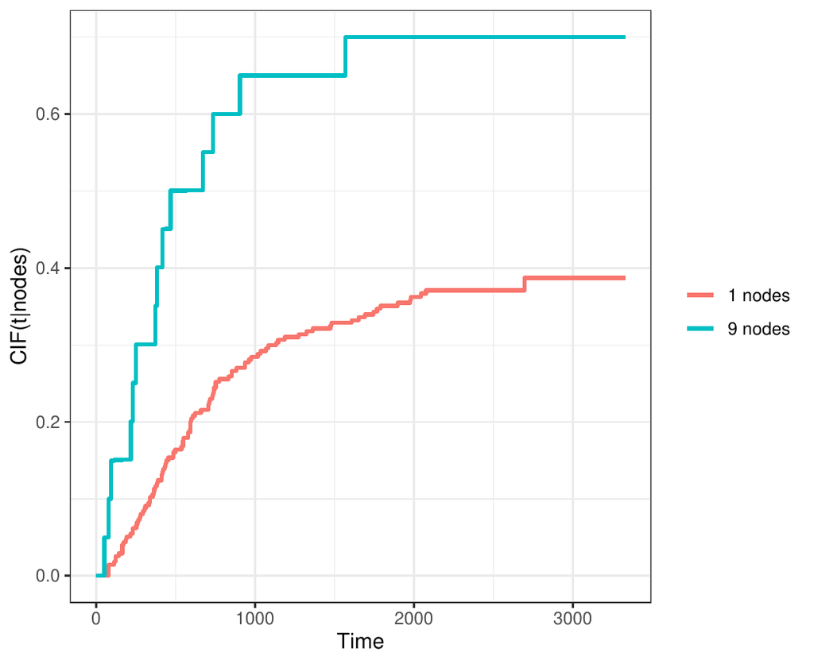

Figure 7: Conditional cumulative incidence function for the colon cancer data for `nodes = 1` and `nodes = 9`, using the colon cancer data.

```r
> cif.1.nodes <- CIF(survIDM(time1, event1, Stime, event) ~ nodes, data = colonIDM,
           conf = FALSE, z.value = 1)
> cif.9.nodes <- CIF(survIDM(time1, event1, Stime, event) ~ nodes, data = colonIDM,
                   conf = FALSE, z.value = 9)

> d<-as.data.frame(cbind(rep(cif.1.nodes$est[,1],2),c(cif.1.nodes$est[,2],
                 cif.9.nodes$est[,2]), c(rep("1 nodes", length(cif.1.nodes$est[,1])),
                 rep("9 nodes", length(cif.1.nodes$est[,2])))))

> names(d)<-c('time','cif','type')

> cif<-ggplot(d, aes(x=as.numeric(time), y=as.numeric(cif),group=factor(type),
                  color=factor(type)))+theme_bw()+labs(x = 'Time (days)',
                  y = 'CIF(t|nodes)')
> cif+geom_step(size=1)+ theme(legend.title=element_blank())
```

## Sojourn distribution

Another interesting quantity is the sojourn time in each state. Estimates for the distribution function of the sojourn time in the recurrence state can be obtained using the estimator by Satten and Datta (2002) through function `sojourn`.

```r
> soj <- sojourn(survIDM(time1, event1, Stime, event) ~ 1,
               data = colonIDM, method = "Satten-Datta", conf = FALSE)
> summary(soj, time=365*1:6)

Estimation of sojourn(t)

    t   sojourn
  365 0.4852424
  730 0.7723636
 1095 0.8755021
 1460 0.8983714
 1825 0.9102335
 2190 0.9220849
```

The methods for implementing some of the proposed methods can be computationally demanding. In particular, the use of bootstrap resampling techniques is time-consuming process because it is necessary to estimate the model a great number of times. In such cases, we recommend the use of parallelization (`cluster = TRUE`). This should considerably increase performance on multi-core/ multi-threading machines.

# Conclusions

There has been several recent contributions for the inference in the context of multi-state models. Many of these contributions were made for the illness-death model. One important and perhaps undervalued aspect of multi-state models is the possibility to apply them to obtain predictions of the clinical prognosis. This is usually achieved using estimates of the transition probabilities and survival estimates. However, there are several other quantities that could also be used in the analysis of these data, such as the state occupation probabilities, the sojourn time distributions, and the cumulative incidence functions. To provide the biomedical researchers with an easy-to-use tool for obtaining predictive estimates for all these quantities, we develop an R package called [*survidm*](https://CRAN.R-project.org/package=survidm). This package can be used to implement several nonparametric and semiparametric estimators for the transition probabilities. In addition, estimators have also implemented that account for the influence of covariates. Bootstrap confidence bands are provided for all methods. The software can also be used to perform multi-state regression (using type-specific Cox models).

One limitation of the [*survidm*](https://CRAN.R-project.org/package=survidm) R package is that it can only be used in the progressive illness-death model. However, this turns out to be an advantage for those users that only wish to analyze data from a progressive illness-death model. For such cases, the [*survidm*](https://CRAN.R-project.org/package=survidm) package is ideal since it is user-friendly (as illustrated in the real data analysis as well as in the help files of the main functions `tprob`, `sojourn`, and `CIF`) with a strong resemblance to the well-known and widely used [*survival*](https://CRAN.R-project.org/package=survival) package.

# Acknowledgments

This research was financed by Portuguese Funds through FCT - "Fundação para a Ciência e a Tecnologia", within the research grant PD/BD/142887/2018. Luís Meira-Machado acknowledges financial support from the Spanish Ministry of Economy and Competitiveness MINECO through project MTM2017-82379-R funded by (AEI/FEDER, UE) and acronym "AFTERAM".

Aalen, O. O., O. Borgan, and H. Fekjaer. 2001. “Covariate Adjustment of Event Histories Estimated from Markov Chains: The Additive Approach.” *Biometrics* 57 (4): 993–1001.

Aalen, O., and S. Johansen. 1978. “An Empirical Transition Matrix for Non Homogeneous Markov and Chains Based on Censored Observations.” *Scandinavian Journal of Statistics* 5: 141–50.

Allignol, A., and A. Latouche. 2018. “CRAN Task View: Survival Analysis.” *Version 2018-05-04, URL Http://CRAN.R-Project.org/View=Survival*.

Allignol, A., M. Schumacher, and J. Beyersmann. 2011. “Empirical Transition Matrix of Multi-State Models: The Etm Package.” *Journal of Statistical Software* 38:4: 1–15.

Andersen, P. K., Ø. Borgan, R. D. Gill, and N. Keiding. 1993. *Statistical Models Based on Counting Processes*. New York: Springer-Verlag.

Araújo, Artur Agostinho, Javier Roca-Pardiñas, and Luı́s Meira-Machado. 2014. “TPmsm: Estimation of the Transition Probabilities in 3-State Models.” *Journal of Statistical Software* 62: 1–29.

Balboa, V., and J. de Uña-Álvarez. 2018. “Estimation of Transition Probabilities for the Illness-Death Model: Package TP.idm.” *Journal of Statistical Software* 83:10: 1–19.

Borgan, Ø. 1988. “Aalen-Johansen Estimator.” *Encyclopedia of Biostatistics* 1: 5–10.

Breslow, N. E. 1972. “Discussion of Paper by DR Cox.” *Journal of Royal Statistical Society, Series B*, 216–17.

Cao, R., I. Lopez-de-Ullibarri, P. Janssen, and N. Veraverbeke. 2005. “Presmoothed Kaplan-Meier and Nelson-Aalen Estimators.” *Journal of Nonparametric Statistics* 17: 31–56.

Cox, D. R. 1972. “Regression Models and Life Tables.” *Journal of the Royal Statistical Society Series B* 34: 187–220.

Datta, S., and G. A. Satten. 2001. “Validity of the Aalen-Johansen Estimators of Stage Occupation Probabilities and Nelson Aalen Integrated Transition Hazards for Non-Markov Models.” *Statistics & Probability Letters* 55: 403–11.

Dikta, G. 1998. “On Semiparametric Random Censorship Models.” *Journal of Statistical Planning and Inference* 66: 253–79.

Eilers, P. H. C., and B. D. Marx. 1996. “Flexible Smoothing with b-Splines and Penalties.” *Statistical Science* 11: 89–121.

Geskus, Ronald B. 2011. “Cause-Specific Cumulative Incidence Estimation and the Fine and Gray Model Under Both Left Truncation and Right Censoring.” *Biometrics* 67 (1): 39–49.

Hougaard, P. 2000. *Analysis of Multivariate Survival Data*. Statistics for Biology and Health. New York: Springer-Verlag.

Jackson, C. H. 2011. “Multi-State Models for Panel Data: The Msm Package for r.” *Journal of Statistical Software* 38:8: 1–28.

Kalbfleisch, John D, and Ross L Prentice. 1980. *The Statistical Analysis of Failure Time Data*. John Wiley & Sons.

Kaplan, E. L., and P. Meier. 1958. “Nonparametric Estimation from Incomplete Observations.” *Journal of the American Statistical Association* 53: 457–81.

Meira-Machado, L., J. de Uña-Álvarez, and C. Cadarso-Suárez. 2006. “Nonparametric Estimation of Transition Probabilities in a Non-Markov Illness-Death Model.” *Lifetime Data Analysis* 12: 325–44.

Meira-Machado, L., and J. Roca-Pardiñas. 2011. “P3state.msm: Analyzing Survival Data from an Illness-Death Model.” *Journal of Statistical Software* 38:3.

Meira-Machado, L., and M. Sestelo. 2019. “Estimation in the Progressive Illness-Death Model: A Nonexhaustive Review.” *Biometrical Journal* 61: 245–63. https://doi.org/10.1002/bimj.201500038.

Meira-Machado, Luis. 2016. “Smoothed Landmark Estimators of the Transition Probabilities.” *SORT-Statistics and Operations Research Transactions* 40 (2): 375–98.

Meira-Machado, L., J. de Uña-Álvarez, C. Cadarso-Suárez, and P. K. Andersen. 2009. “Multi-State Models for the Analysis of Time to Event Data.” *Statistical Methods in Medical Research* 18: 195–222.

Meira-Machado, L., J. de Uña-Álvarez, and S. Datta. 2015. “Nonparametric Estimation of Conditional Transition Probabilities in a Non-Markov Illness-Death Model.” *Computational Statistics* 30: 377–97.

Moertel, Charles G., Thomas R. Fleming, John S. Macdonald, Daniel G. Haller, John A. Laurie, Phyllis J. Goodman, James S. Ungerleider, et al. 1990. “Levamisole and Fluorouracil for Adjuvant Therapy of Resected Colon Carcinoma.” *New England Journal of Medicine* 322 (6): 352–58.

Moreira, Ana, Jacobo de Uña-Álvarez, and Luis Meira-Machado. 2013. “Presmoothing the Aalen-Johansen Estimator in the Illness-Death Model.” *Electronical Journal of Statistics* 7: 1491–1516.

Putter, H., M. Fiocco, and R. B. Geskus. 2007. “Tutorial in Biostatistics: Competing Risks and Multi-State Models.” *Statistics in Medicine* 26 (11): 2389–2430.

Putter, H, and C Spitoni. 2018. “Non-Parametric Estimation of Transition Probabilities in Non-Markov Multi-State Models: The Landmark Aalen-Johansen Estimator.” *Statistical Methods in Medical Research* 27: 2081–92.

R Core Team. 2019. *R: A Language and Environment for Statistical Computing*. Vienna, Austria: R Foundation for Statistical Computing. https://www.r-project.org/.

Rodríguez-Álvarez, M. X., L. Meira-Machado, and E. Abu-Assi. 2016. “Nonparametric Estimation of Time-Dependent ROC Curves Conditional on a Continuous Covariate.” *Statistics in Medicine* 35:7: 1090–1102.

Satten, G. A., and S. Datta. 2002. “Marginal Estimation for Multi-Stage Models: Waiting Time Distributions and Competing Risks Analyses.” *Statistics in Medicine* 21 (1): 3–19.

Therneau, Terry M. 2021. *A Package for Survival Analysis in r*. https://CRAN.R-project.org/package=survival.

Uña-Álvarez, Jacobo de, and Luis Meira-Machado. 2015. “Nonparametric Estimation of Transition Probabilities in the Non-Markov Illness-Death Model: A Comparative Study.” *Biometrics* 71 (2): 364–75.

Van Houwelingen, Hans C. 2007. “Dynamic Prediction by Landmarking in Event History Analysis.” *Scandinavian Journal of Statistics* 34 (1): 70–85.

Wand, M. P., and M. C. Jones. 1997. *Kernel Smoothing*. London: Chapman & Hal.

Wei, L. J. 1992. “The Accelerated Failure Time Model: A Useful Alternative to the Cox Regression Model in Survival Analysis.” *Statist. Med.* 11: 1871–79.

Wreede, L. de, M. Fiocco, and H. Putter. 2011. “Mstate: An r Package for the Analysis of Competing Risks and Multi-State Models.” *Journal of Statistical Software* 38:7: 1–30.